# Trabajo Final

Autores

Kevin Jay Herrera [kjayh@unal.edu.co]

c.c 1007340307

Omar Chavez

c.c 1123637665

Yesid Lopez

c.c

Fecha de Publicación

17 de noviembre de 2022

## Base de datos

Resumen de la base de datos E-14

##Puesto de I.E. RAFAEL URIBE URIBE

En el siguiente apartado encontramos la votación de los habitantes de las zonas asignadas (24,25,26) dividida por la primera mitad de mesas que corresponde a las personas de mayor edad, y la segunda mitad que corresponde a los más jóvenes. A partir de estos datos podremos analizar como se comporta la elección por parte de los residentes del departamento de Antioquia dependiendo de su rango de edad, teniendo que la primera gráfica en cada puesto corresponde a las personas de mayor edad, y la segunda gráfica corresponde a los más jóvenes, tenemos lo siguiente:

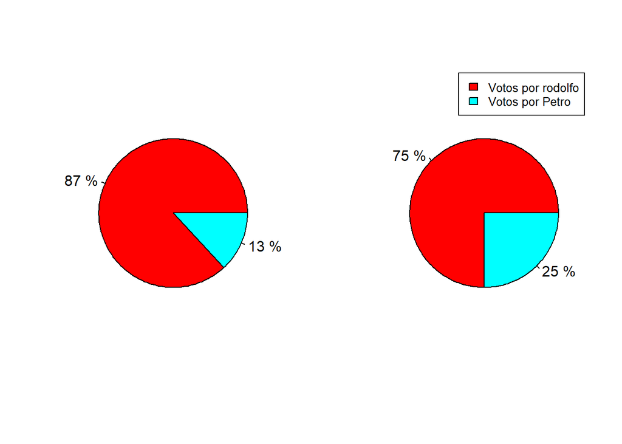

## Puesto SEC.ESC.RAFAEL URIBE URIBE

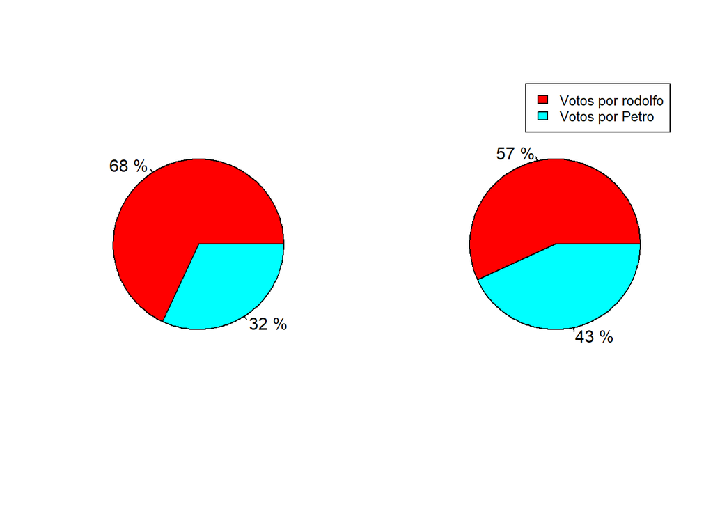

## Puesto de SEC. ESC. PEDRO DE CASTRO

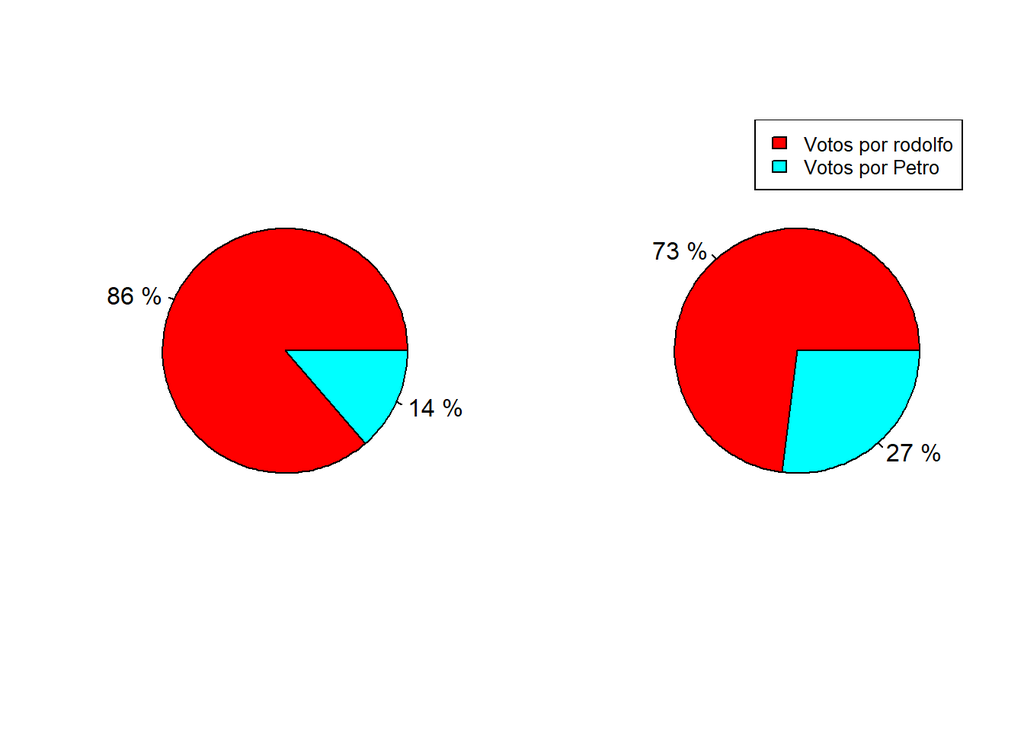

##Puesto de I.E.FRANCISCO ANTONIO ZEA

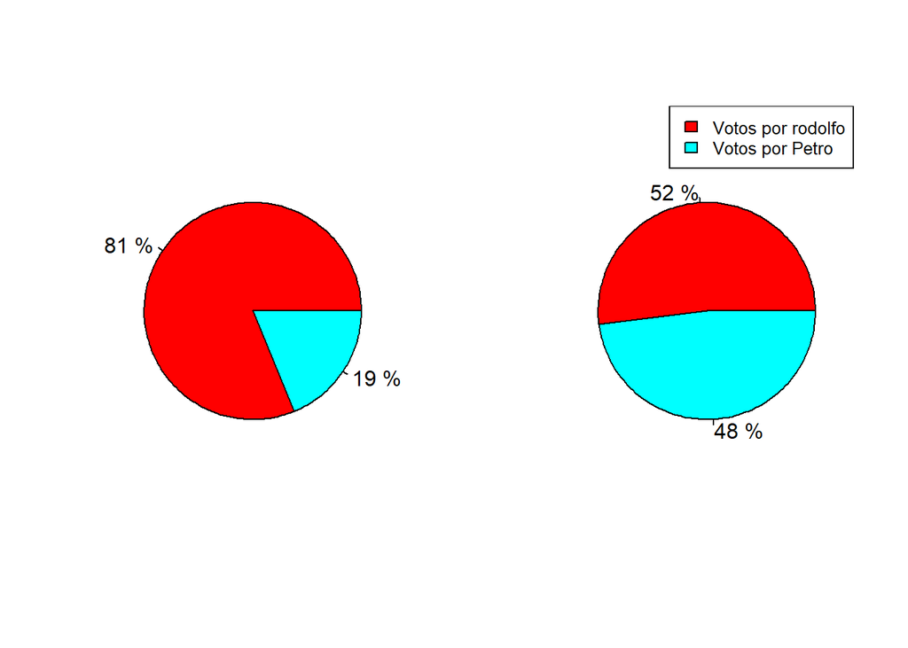

##Puesto de I.E. AMERICA

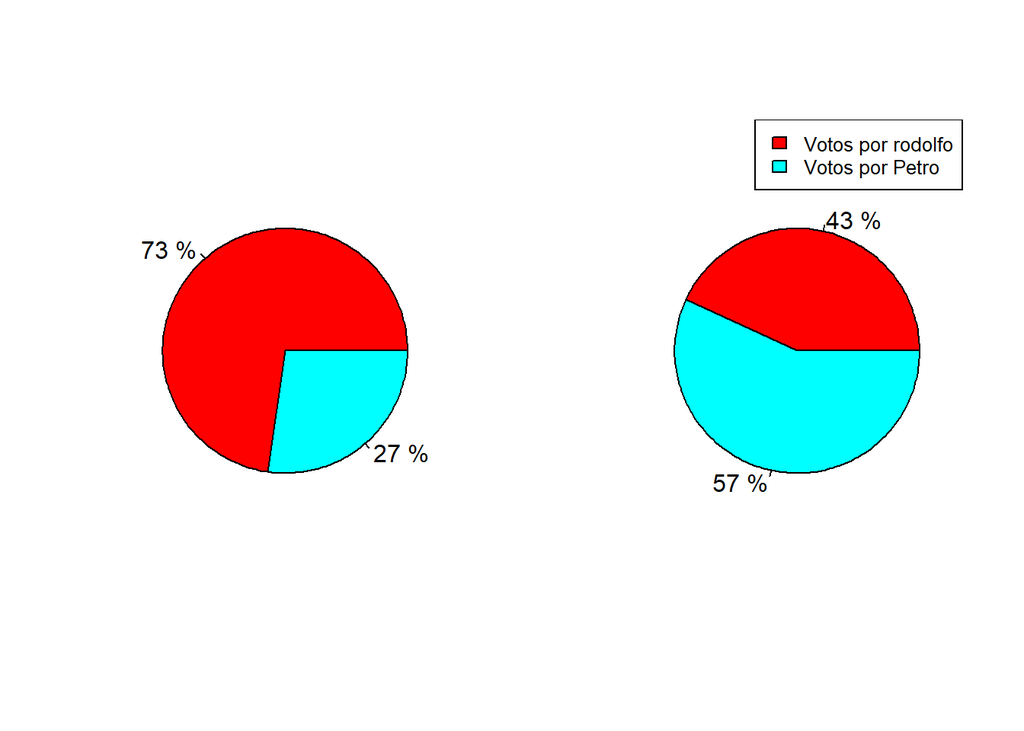

## Puesto de I.E.SAMUEL BARRIENTOS

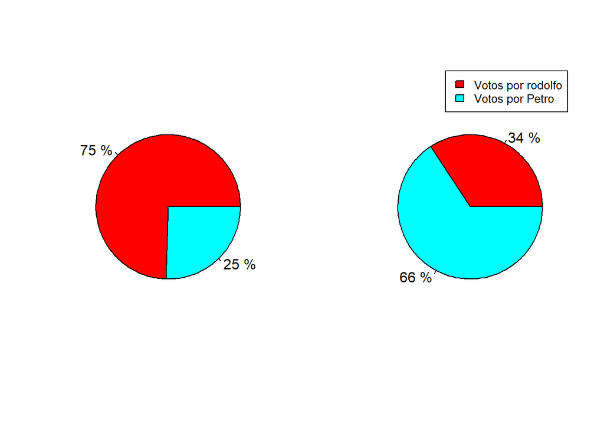

##Puesto de LICEO SALAZAR Y HERRERA

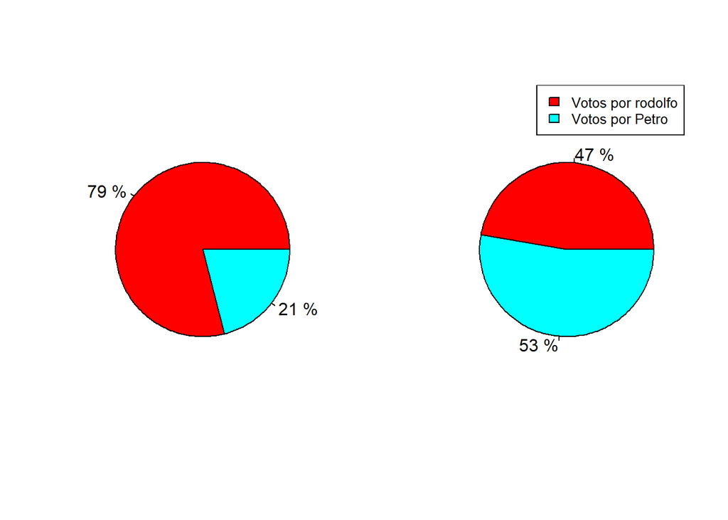

##Puesto de I.E BLANQUIZAL

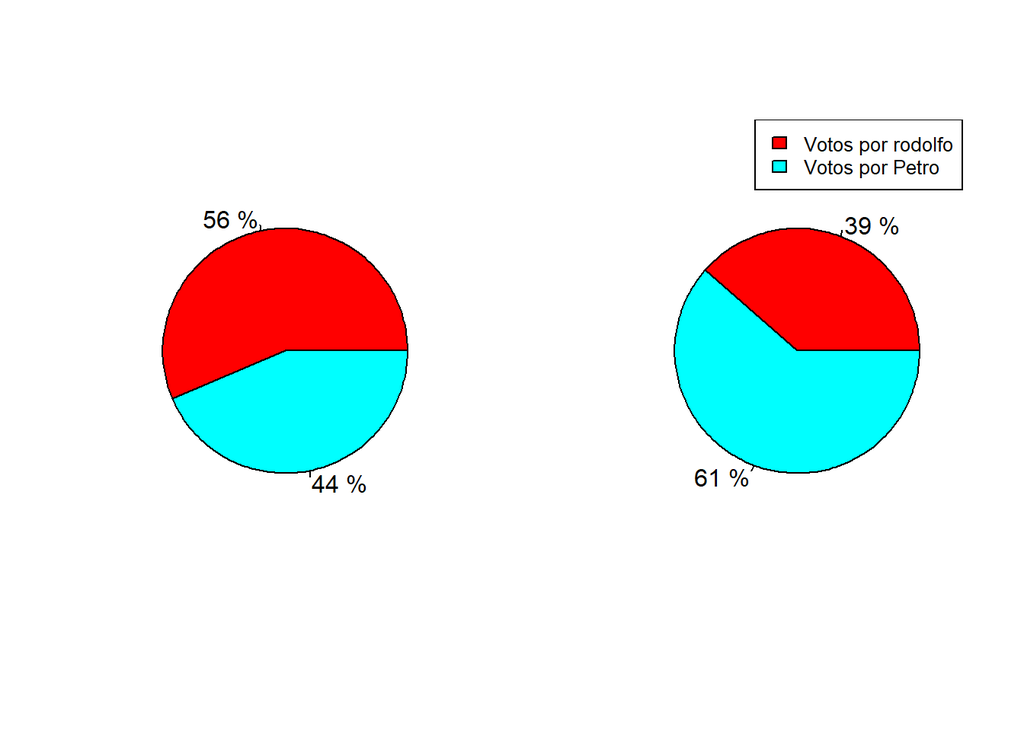

##Puesto de SEC. ESC. REPUBLICA DE PANAMA

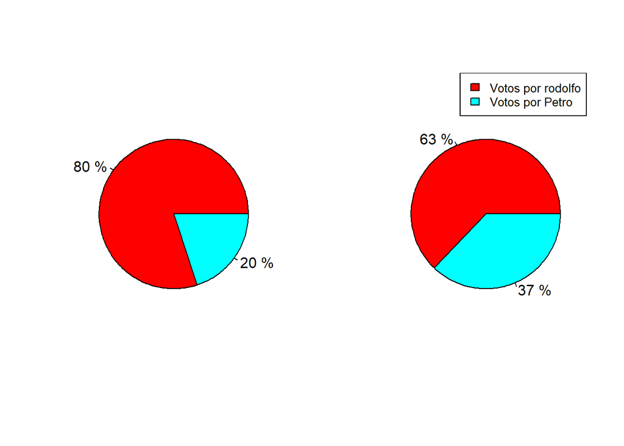

Puesto de I.E JUAN XXIII

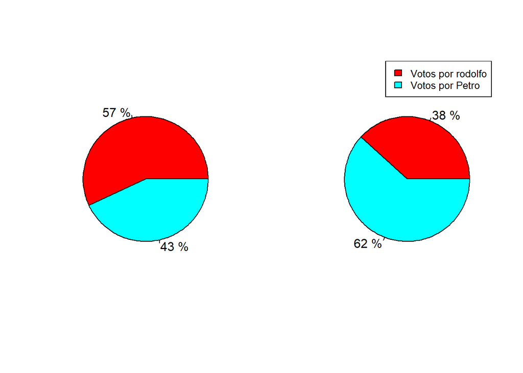

##Puesto de SEC. ESC. MONSEÑOR PERDOMO

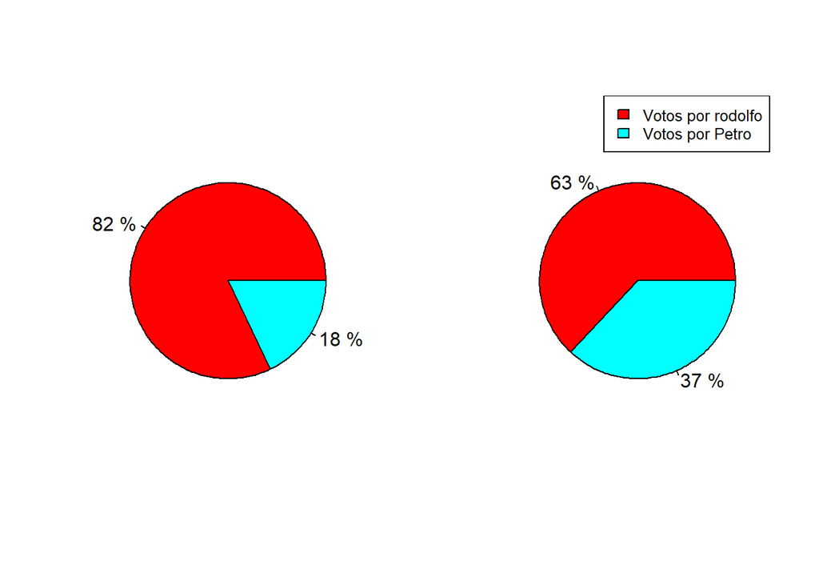

##Puesto de SEC. ESC. PIO XII

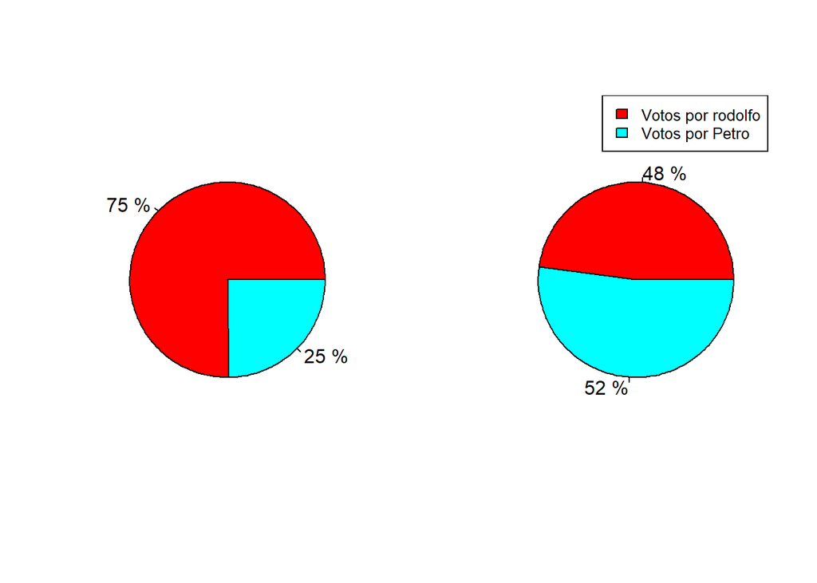

##Puesto de I.E STELLA VELEZ LONDOÑO

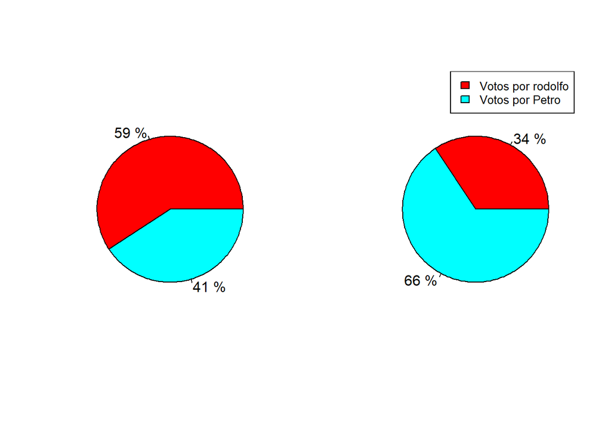

##Puesto de SEC. ESC. JUAN DE DIOS ARANZAZU

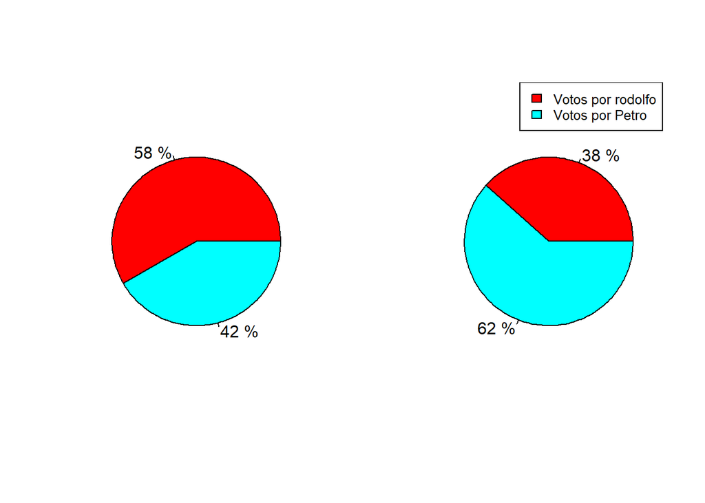

##Puesto de I.E. LA INDEPENDENCIA

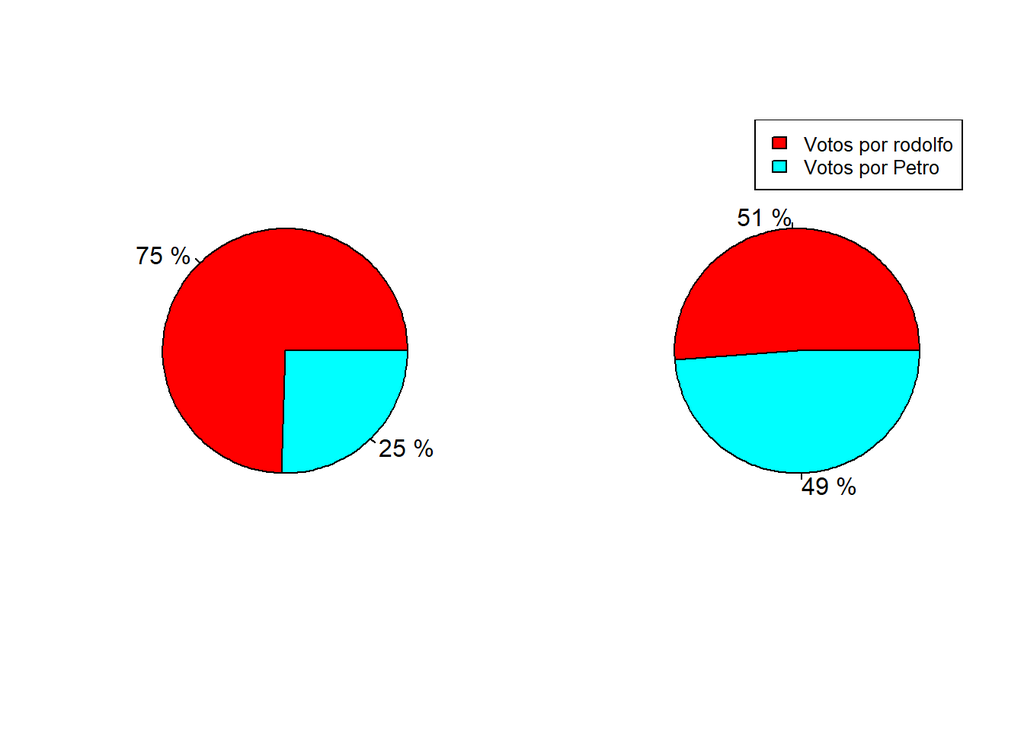

##Puesto de SEC.ESC. EL SOCORRO

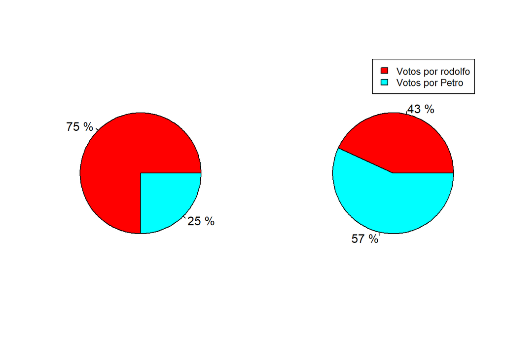

##Puesto de SEC.ESC. MIXTA BETANIA

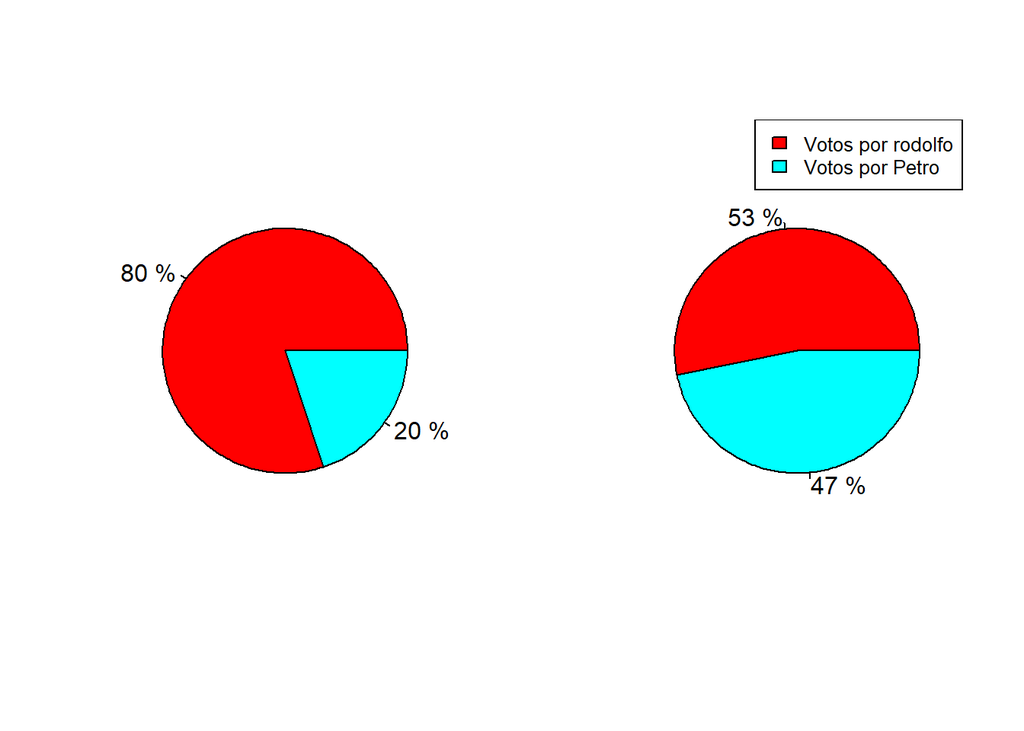

##Puesto de I.E. EL CORAZON

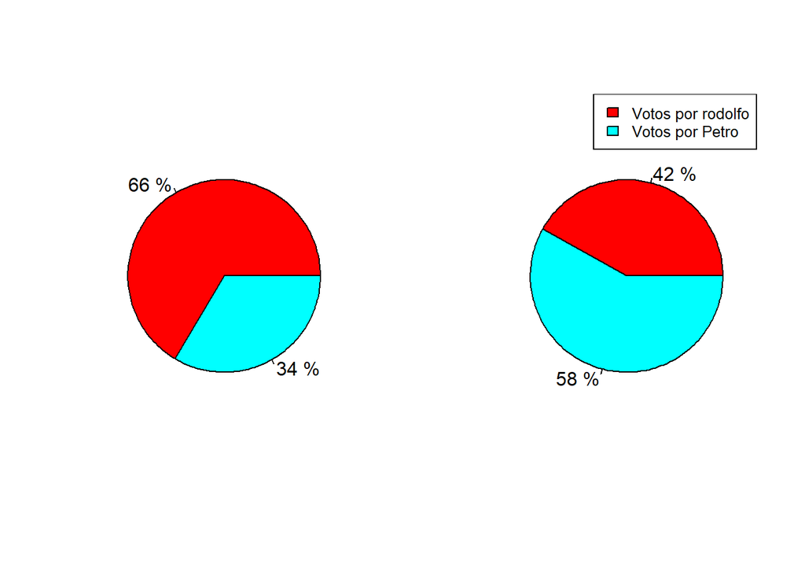

##Puesto de I.E. EDUARDO SANTOS

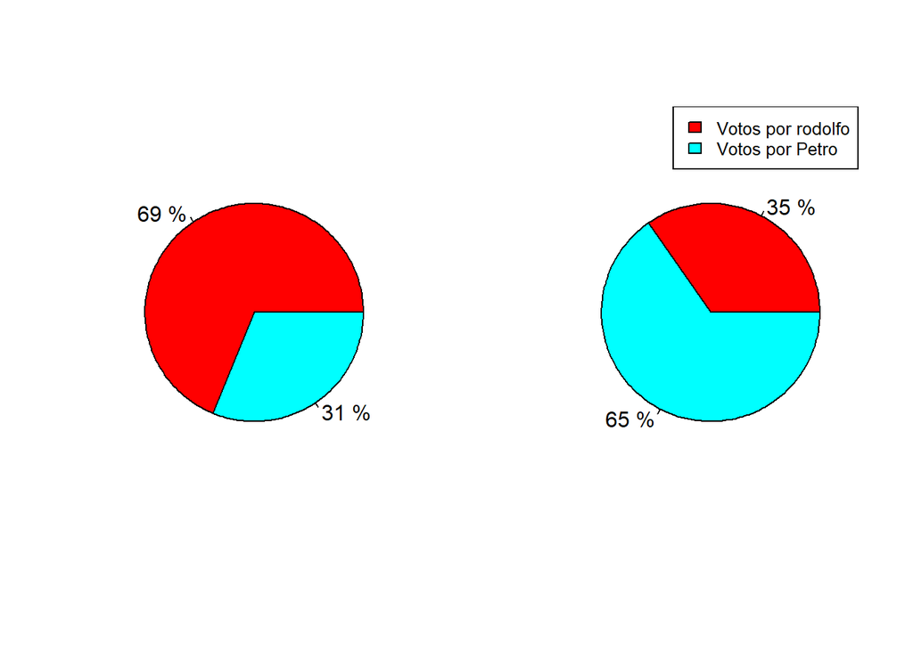

##Puesto de I.E. CARLOS VIECO

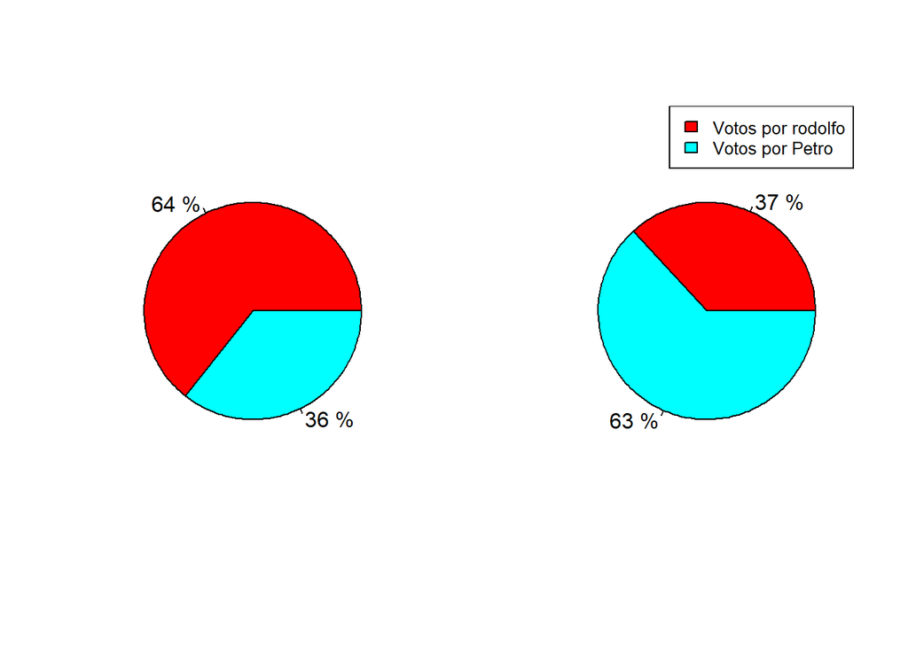

##Puesto de SEDE AMOR AL NIÑO

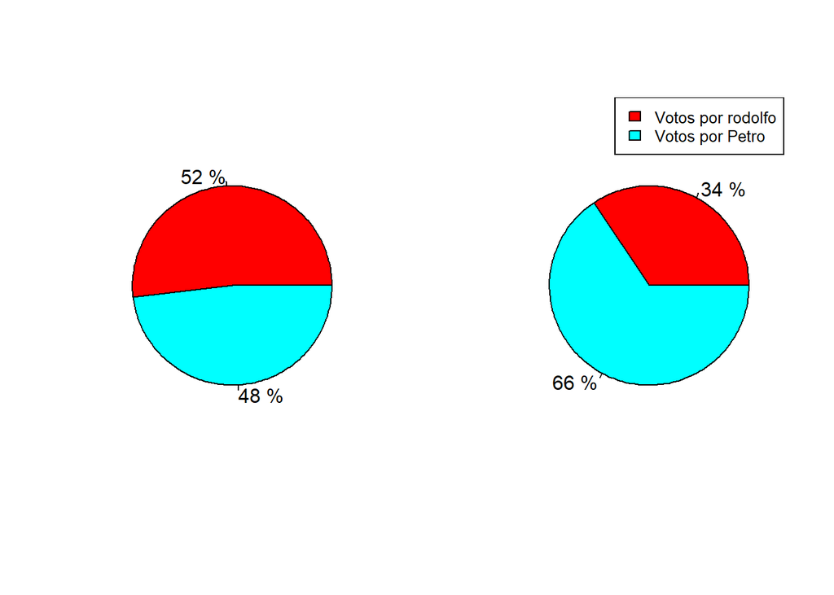

[figure not shown]

## Puesto de SEC. ESC. PEDRO DE CASTRO

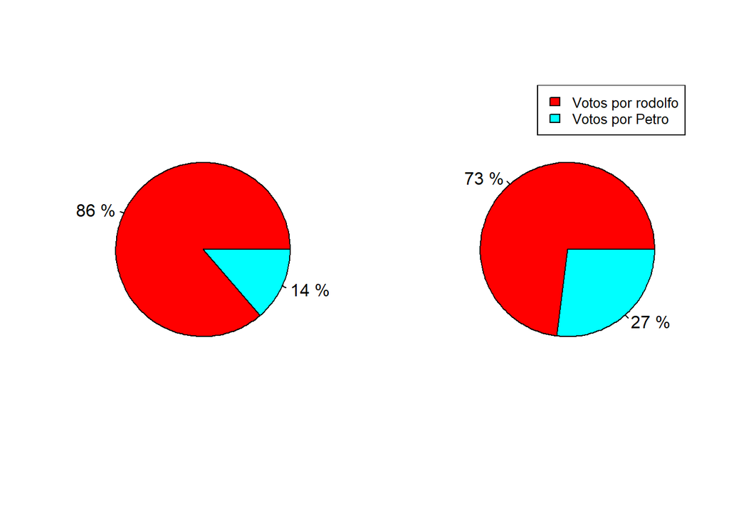

##Puesto de I.E.FRANCISCO ANTONIO ZEA

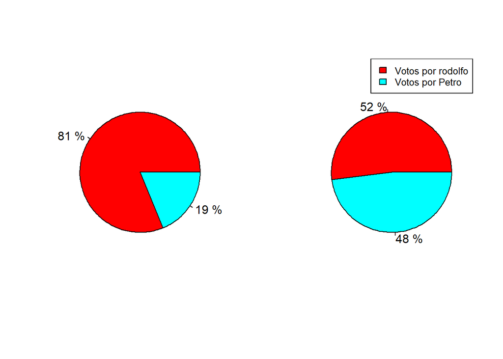

##Puesto de I.E. AMERICA

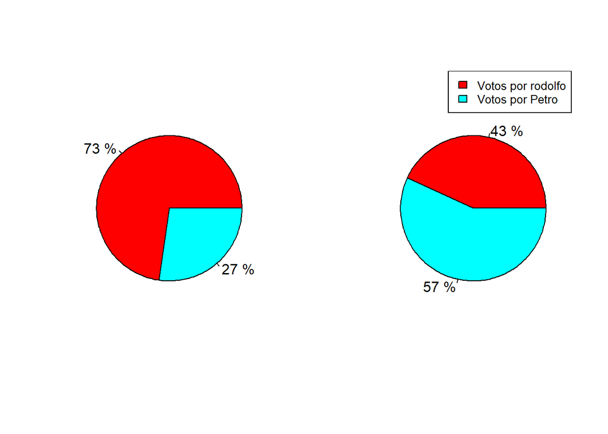

## Puesto de I.E.SAMUEL BARRIENTOS

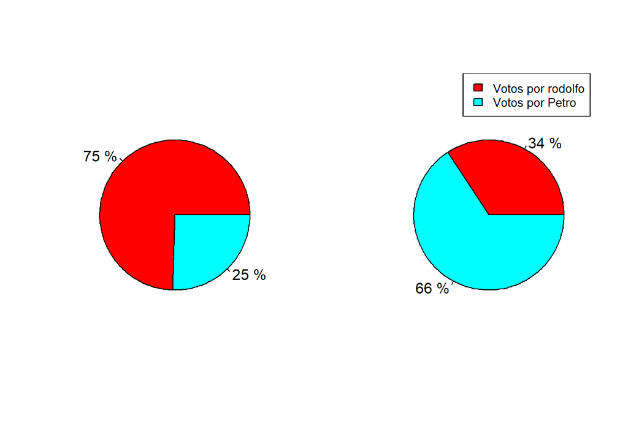

##Puesto de LICEO SALAZAR Y HERRERA

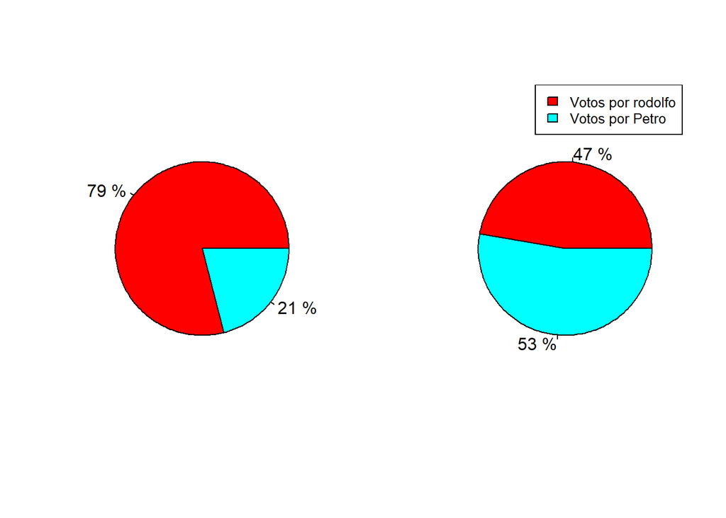

##Puesto de I.E BLANQUIZAL

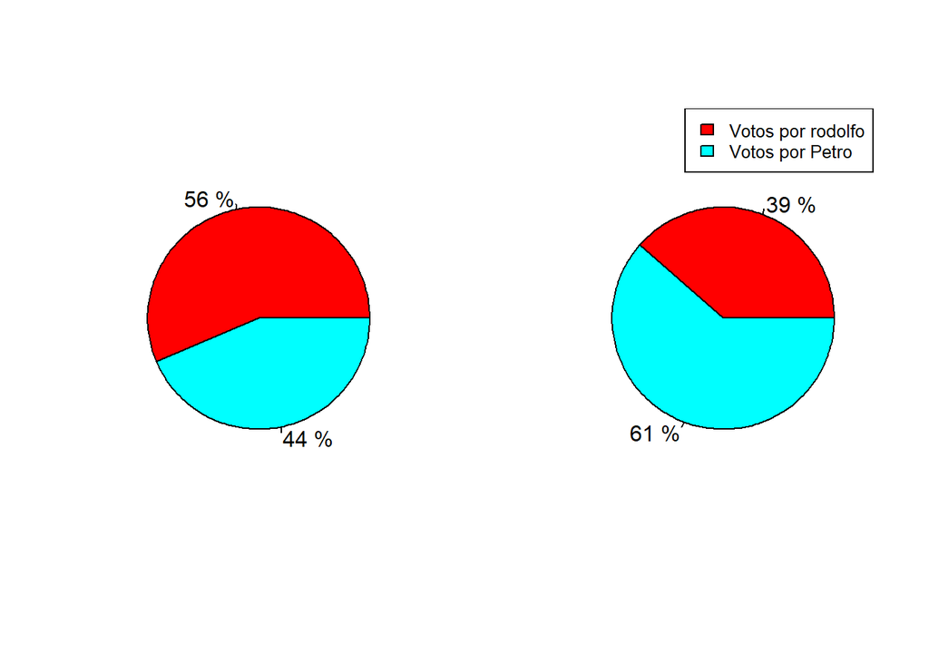

##Puesto de SEC. ESC. REPUBLICA DE PANAMA

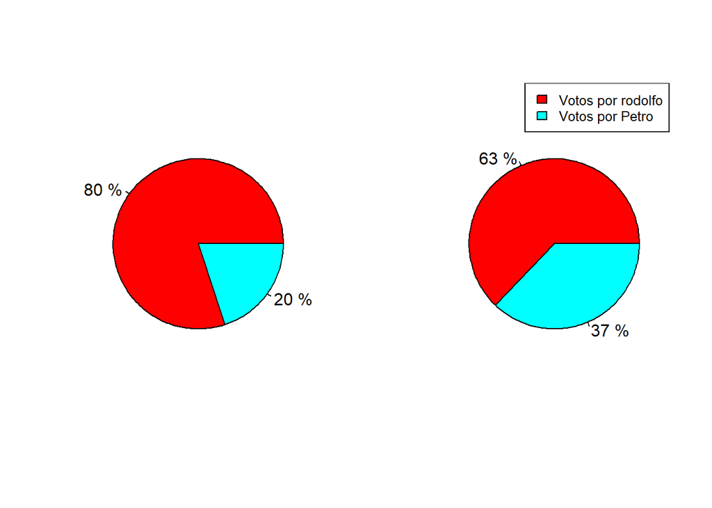

Puesto de I.E JUAN XXIII

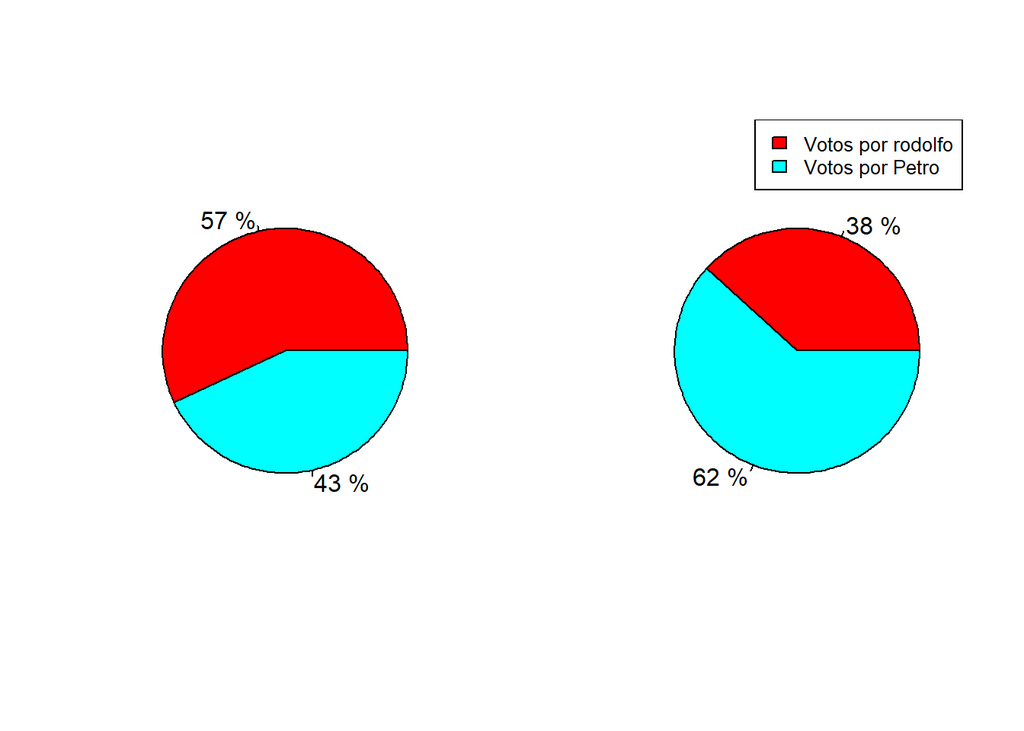

##Puesto de SEC. ESC. MONSEÑOR PERDOMO

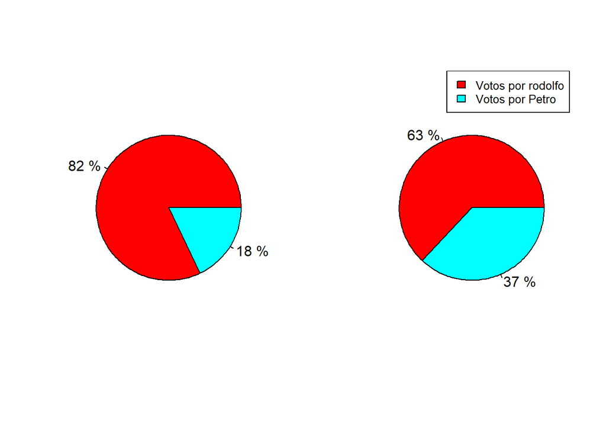

##Puesto de SEC. ESC. PIO XII

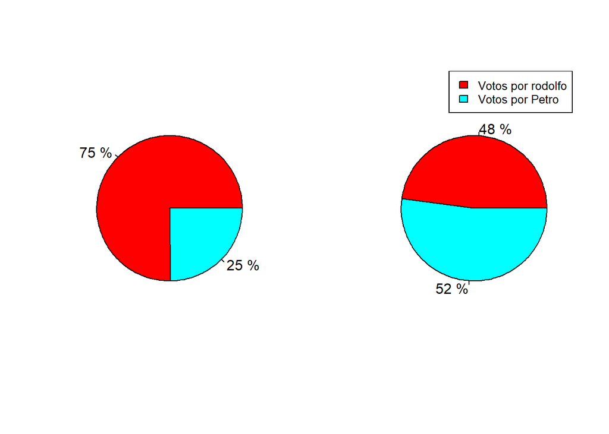

##Puesto de I.E STELLA VELEZ LONDOÑO

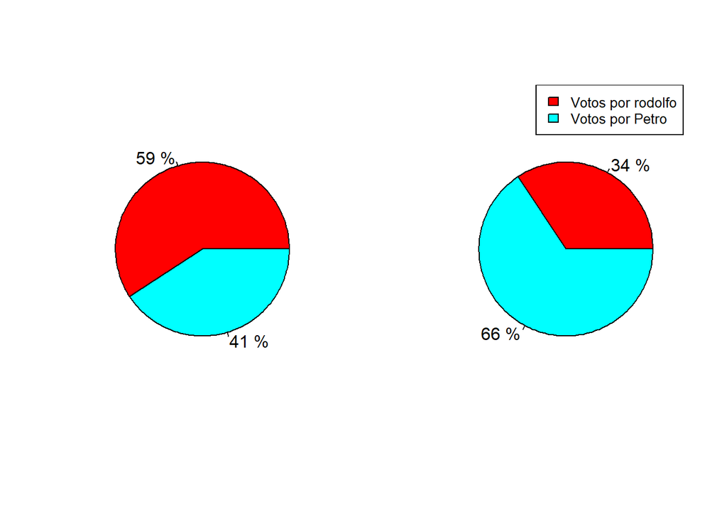

##Puesto de SEC. ESC. JUAN DE DIOS ARANZAZU

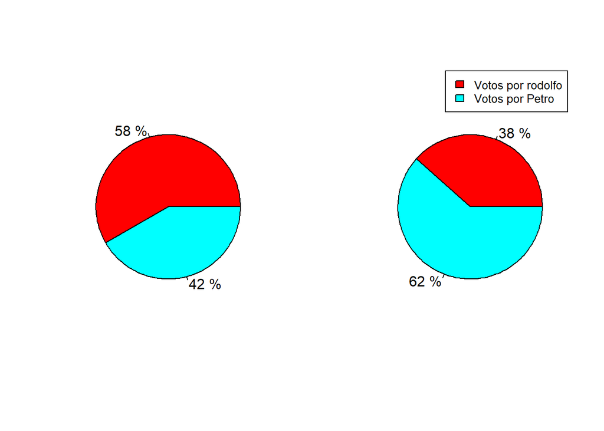

##Puesto de I.E. LA INDEPENDENCIA

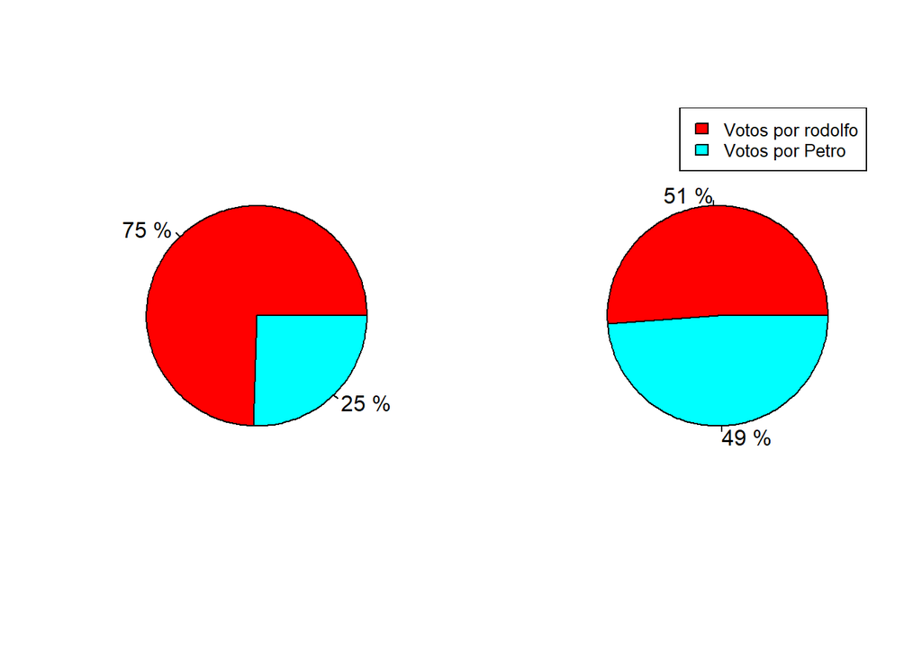

##Puesto de SEC.ESC. EL SOCORRO

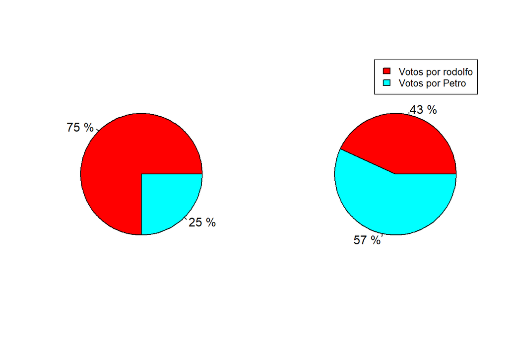

##Puesto de SEC.ESC. MIXTA BETANIA

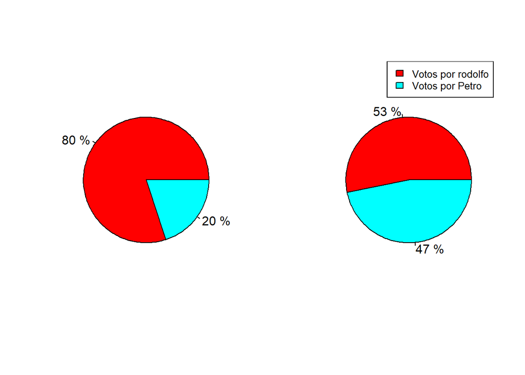

##Puesto de I.E. EL CORAZON

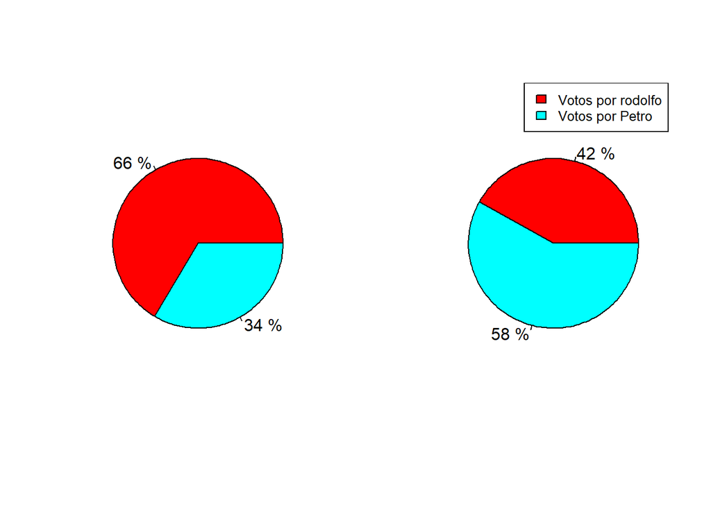

##Puesto de I.E. EDUARDO SANTOS

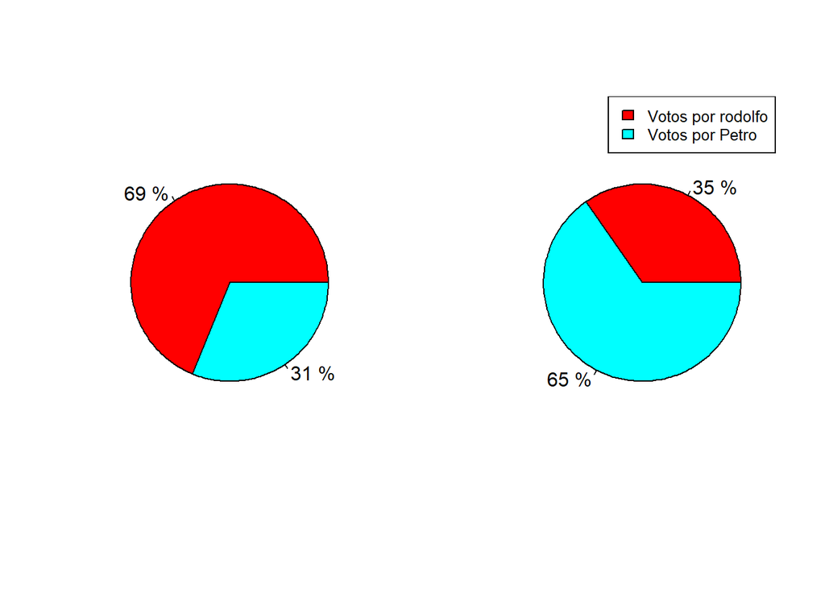

##Puesto de I.E. CARLOS VIECO

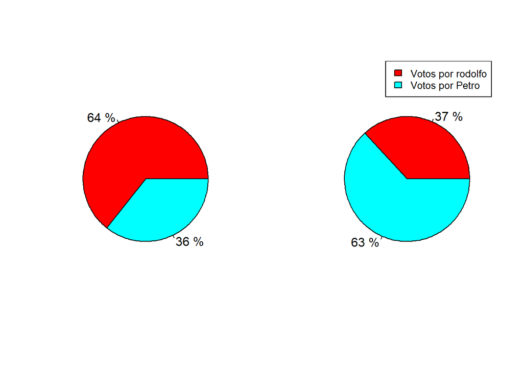

##Puesto de SEDE AMOR AL NIÑO

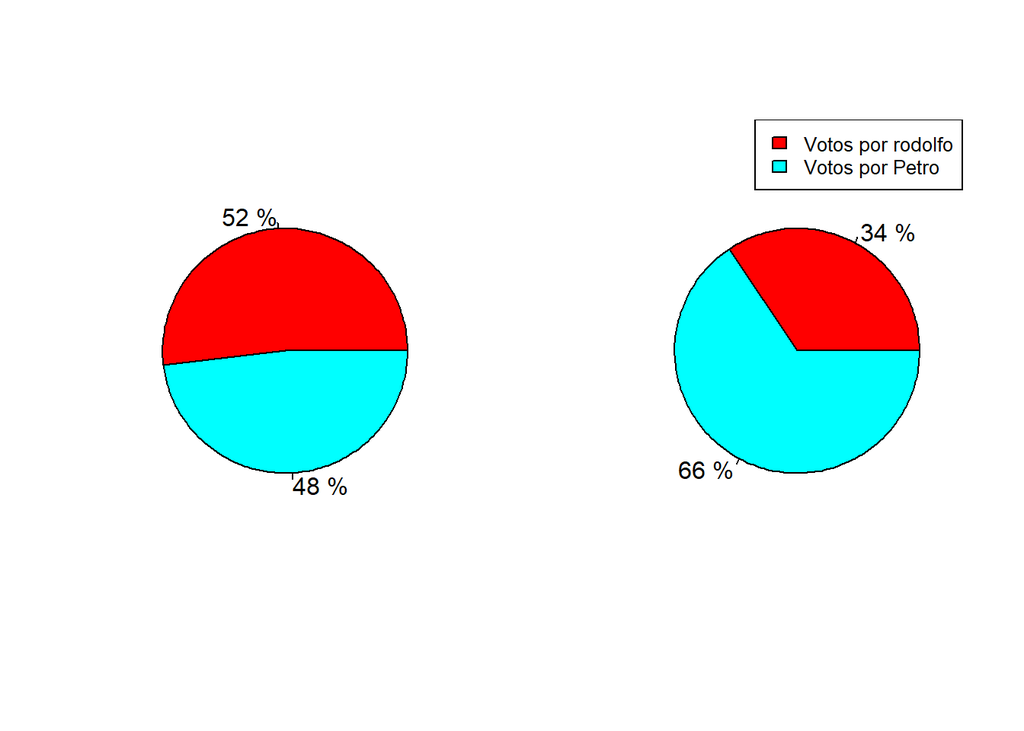

## Despliegue de mapas

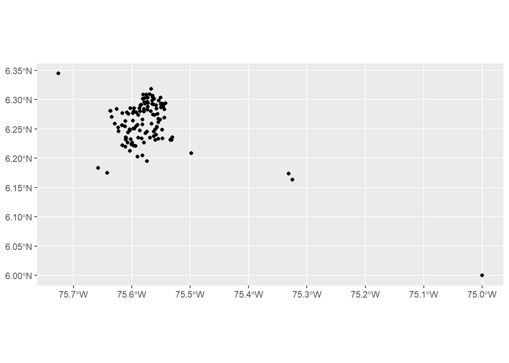

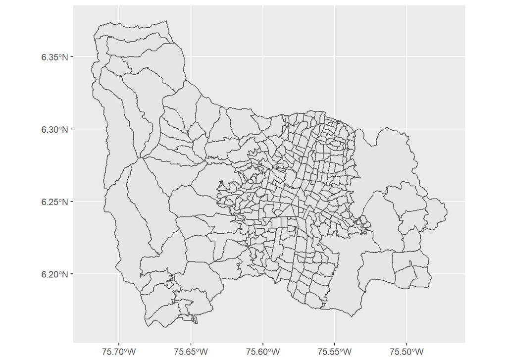

## Integración de mapas

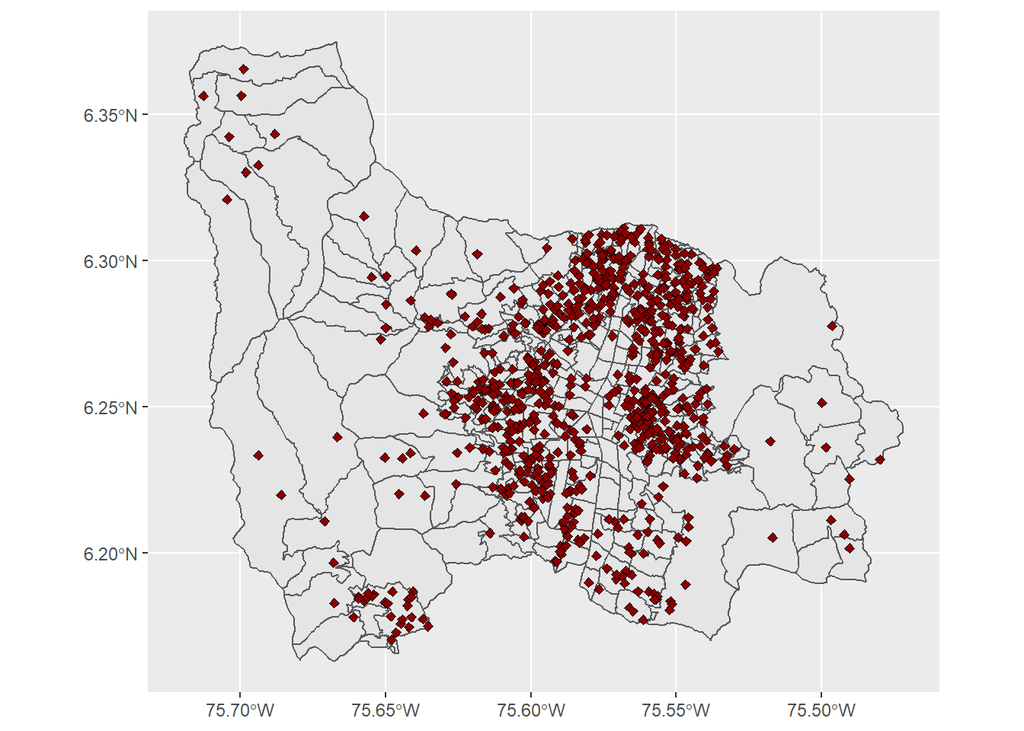

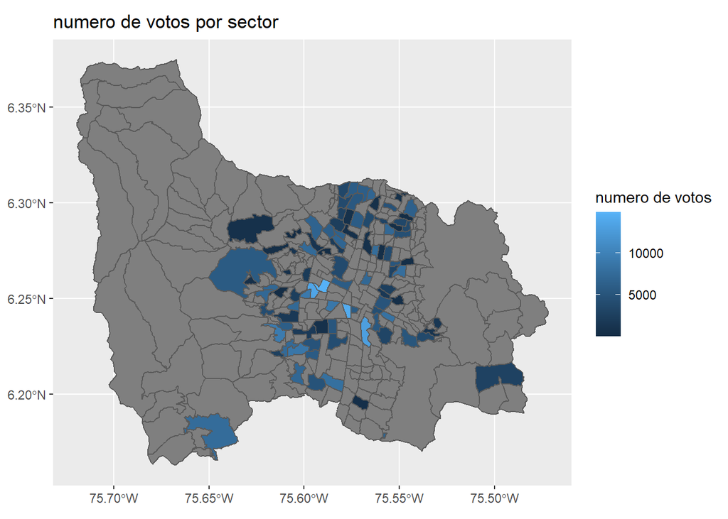

## Union de los mapas

```
    CODIGO             NOMBRE           ABREVIATUR         IDENTIFICA
 Length:355         Length:355         Length:355         Length:355
 Class :character   Class :character   Class :character   Class :character
 Mode  :character   Mode  :character   Mode  :character   Mode  :character




  LIMITECOMU         ZHFISICAGE         LIMITEMUNI         VIGENCIA_F
 Length:355         Length:355         Length:355         Length:355
 Class :character   Class :character   Class :character   Class :character
 Mode  :character   Mode  :character   Mode  :character   Mode  :character




   SUBTIPO_BA     LINK_DOCUM                 geometry      ...12
 Min.   :1.000   Length:355         MULTIPOLYGON :355   Length:355
 1st Qu.:1.000   Class :character   epsg:4326    :  0   Class :character
 Median :1.000   Mode  :character   +proj=long...:  0   Mode  :character
 Mean   :1.177
 3rd Qu.:1.000
 Max.   :2.000

    NDepto             NMpio                PP                  ZZ
 Length:355         Length:355         Length:355         Min.   : 1.00
 Class :character   Class :character   Class :character   1st Qu.:10.00
 Mode  :character   Mode  :character   Mode  :character   Median :16.00
                                                          Mean   :23.76
                                                          3rd Qu.:26.00
                                                          Max.   :99.00
                                                          NA's   :238
   Npuesto            num_mesas       num_votos      estudiante
 Length:355         Min.   : 1.00   Min.   :   32   Length:355
 Class :character   1st Qu.: 8.00   1st Qu.: 1709   Class :character
 Mode  :character   Median :24.00   Median : 4073   Mode  :character
                    Mean   :24.79   Mean   : 4398
                    3rd Qu.:36.00   3rd Qu.: 6451
                    Max.   :85.00   Max.   :14862
                    NA's   :238     NA's   :238
   longitudS         latitudS      ErrelLongitud       ErrelLatitud
 Min.   :-75.67   Min.   :-1.000   Min.   :   0.000   Min.   :  0.0000
 1st Qu.:-75.61   1st Qu.: 6.240   1st Qu.:   0.000   1st Qu.:  0.0000
 Median :-75.58   Median : 6.262   Median :   0.003   Median :  0.0010
 Mean   :-74.95   Mean   : 6.199   Mean   :  63.738   Mean   :  6.3020
 3rd Qu.:-75.56   3rd Qu.: 6.285   3rd Qu.:   0.004   3rd Qu.:  0.0171
 Max.   : -1.00   Max.   : 6.309   Max.   :7456.444   Max.   :730.3889
 NA's   :238      NA's   :238      NA's   :238        NA's   :238
```

[output not shown]

[output cut: 214 more lines]

```
 Max.   :84.84        Max.   :4.000       Max.   :4.000
 NA's   :13945        NA's   :13945       NA's   :49
             ESTU_ESTADOINVESTIGACION
 PUBLICAR                :504828
 VALIDEZ OFICINA JURÍDICA:    44





                               ESTU_GENERACION.E
 GENERACION E - EXCELENCIA DEPARTAMENTAL:   186
 GENERACION E - EXCELENCIA NACIONAL     :  4584
 GENERACION E - GRATUIDAD               :244263
 NO                                     :255839
```